# odi-batting

# bar chart of country wise count of players in descending order of total players

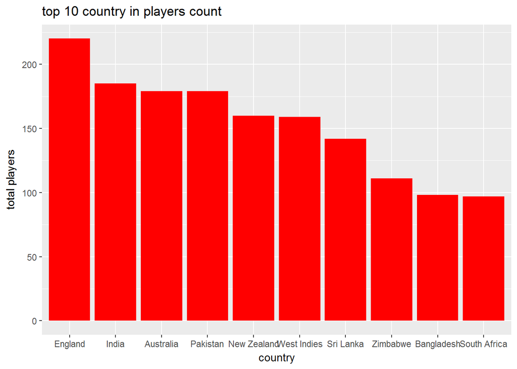

```r
ggplot(country_players[1:10,],aes(x=reorder(Country,-totalplayers),y=totalplayers))+geom_bar(stat="identity",fill="red")+xlab("country")+ylab("total players")+ggtitle("top 10 country in players count")
```

# bar chart of top 10 countries by total runs scored in descending order

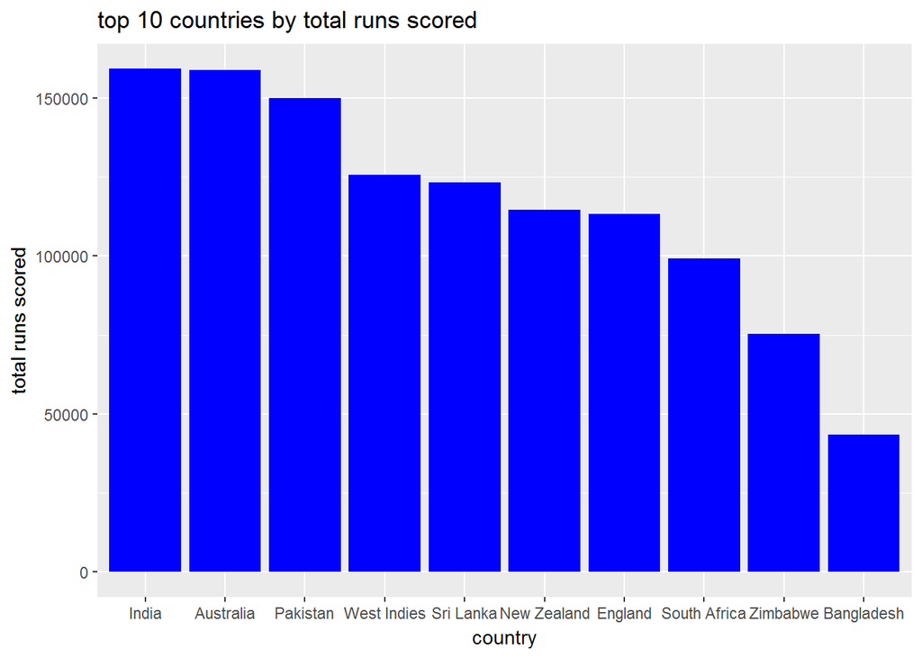

```r
ggplot(country_wise_runs[1:10,],aes(x=reorder(Country,-totalruns),y=totalruns))+geom_bar(stat = "identity",fill="blue")+xlab("country")+ylab("total runs scored")+ggtitle("top 10 countries by total runs scored")
```

# horizontal bar chart of top 10 country with highest average score rate

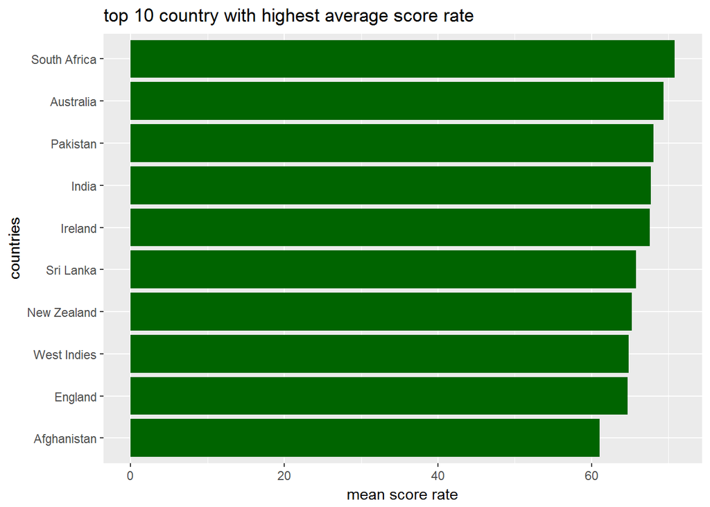

```r
ggplot(country_wise_scorerate[1:10,],aes(x=reorder(Country,mean_scorerate),y=mean_scorerate))+geom_bar(stat="identity",fill="dark green")+xlab("countries")+ylab("mean score rate")+ggtitle("top 10 country with highest average score rate")+coord_flip()
```

# bar chart of top 10 country with max matches played in 2010

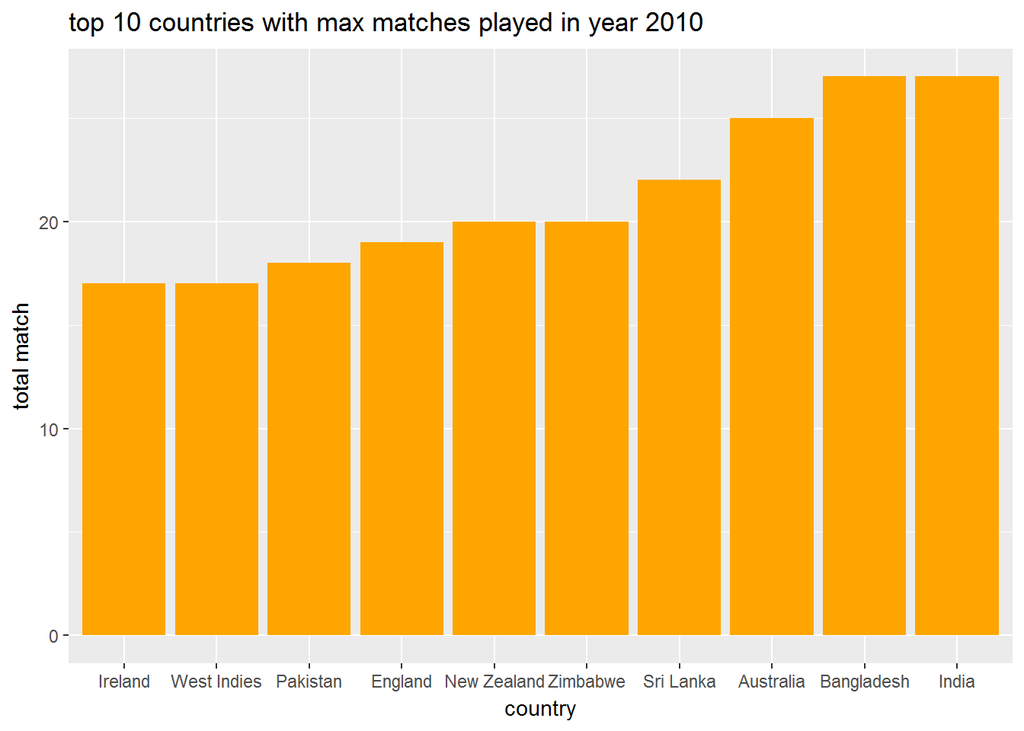

```r
ggplot(country_match[1:10,],aes(x=reorder(Country,totalmatch),y=totalmatch))+geom_bar(stat="identity",fill="orange")+xlab("country")+ylab("total match")+ggtitle("top 10 countries with max matches played in year 2010")
```

# bar chart of top countries with max matches played in lord’s

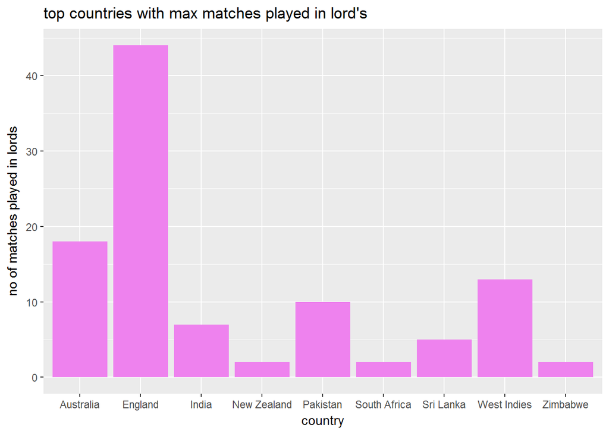

```r
ggplot(country_lords,aes(x=Country,y=lords_match))+geom_bar(stat="identity",fill="violet")+xlab("country")+ylab("no of matches played in lords")+ggtitle("top countries with max matches played in lord's")
```

# bar chart of top 10 countries with max matches played against india

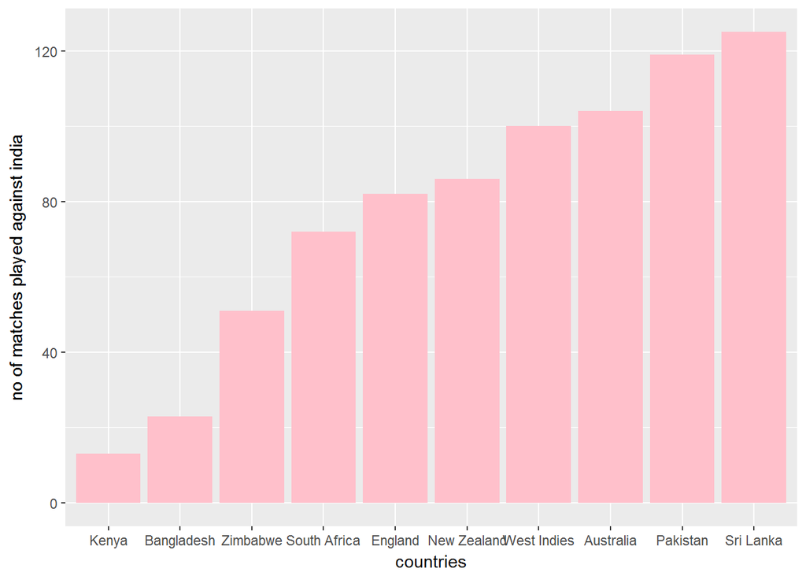

```r
ggplot(country_against_india[1:10,],aes(x=reorder(Country,against_india),y=against_india))+geom_bar(stat="identity",fill="pink")+xlab("countries")+ylab("no of matches played against india")
```

# bar chart of players with highest odi runs

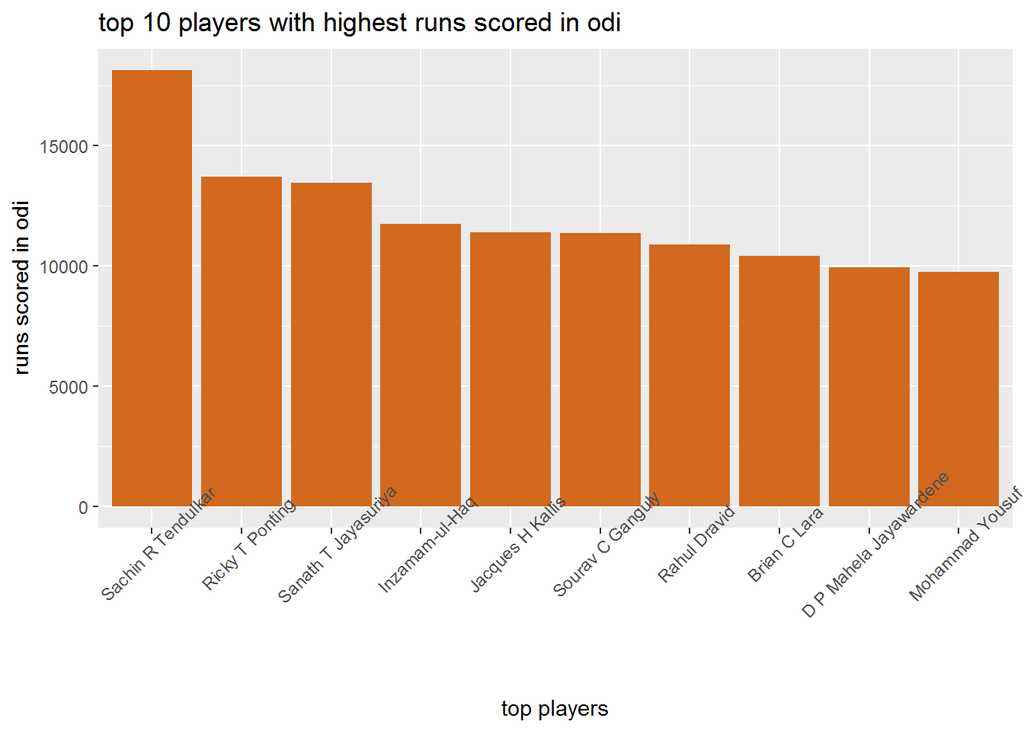

```r
ggplot(player_runs[1:10,],aes(x=reorder(Player,-totalruns),y=totalruns))+geom_bar(stat="identity",fill="chocolate")+xlab("top players")+ylab("runs scored in odi")+ggtitle("top 10 players with highest runs scored in odi")+theme(axis.text.x = element_text(angle = 45))
```

# bar chart of top 10 players with highest average score rate

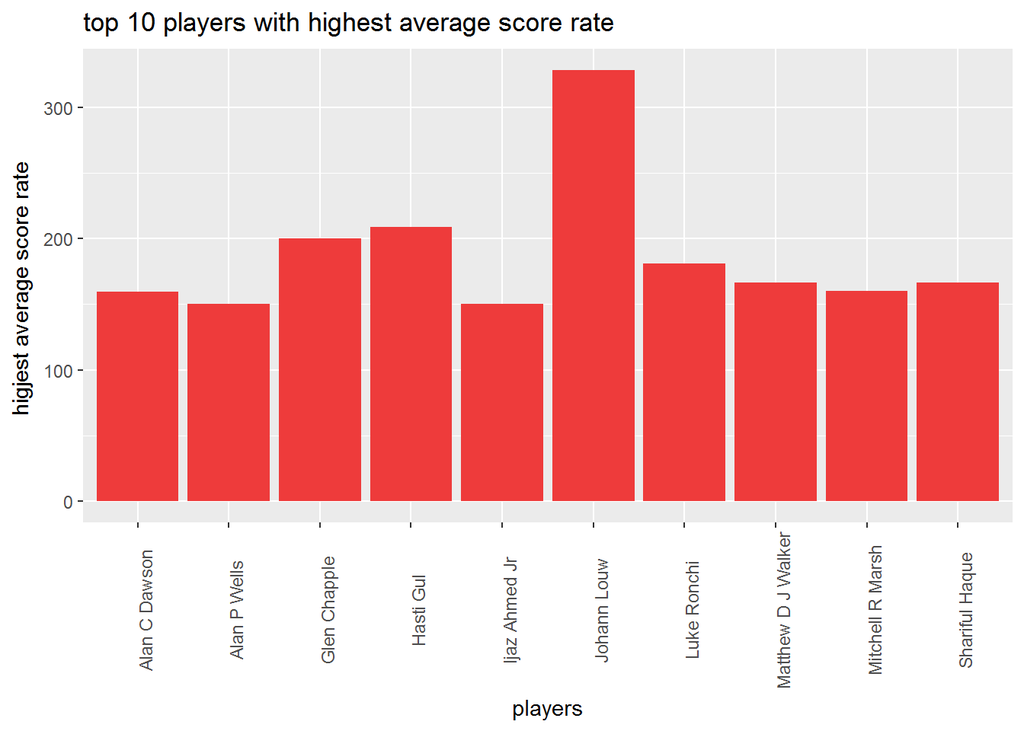

```r
ggplot(player_scorerate[1:10,],aes(x=Player,y=avg_scorerate))+geom_bar(stat="identity",fill="brown2")+theme(axis.text.x = element_text(angle = 90))+xlab("players")+ylab("higjest average score rate ")+ggtitle("top 10 players with highest average score rate")
```

# grouped bar chart of country wise top 10 players by total runs scored

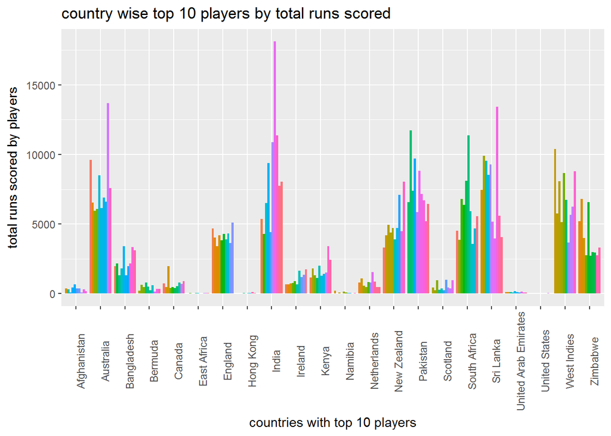

```r
ggplot(country_top_scorer,aes(x=Country,y=totalruns))+geom_bar(aes(fill=Player),position = "dodge",stat="identity") + theme(legend.position = "None")+theme(axis.text.x = element_text(angle = 90))+xlab("countries with top 10 players")+ylab("total runs scored by players")+ggtitle("country wise top 10 players by total runs scored")
```

# bar chart of top 10 players by centuries scored

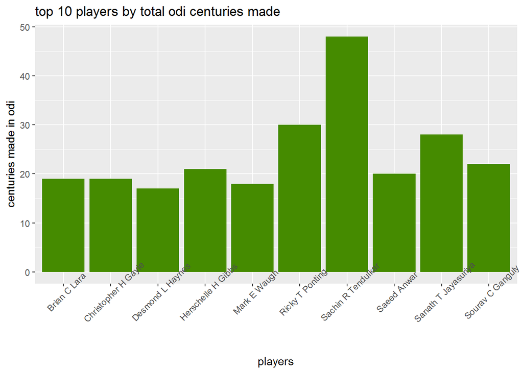

```r
ggplot(player_century[1:10,],aes(x=Player,y=centuries))+geom_bar(stat="identity",fill="chartreuse4")+xlab("players")+ylab("centuries made in odi")+ggtitle("top 10 players by total odi centuries made")+theme(axis.text.x = element_text(angle = 45))
```

# grouped bar chart of country wise top 10 players by centuries made

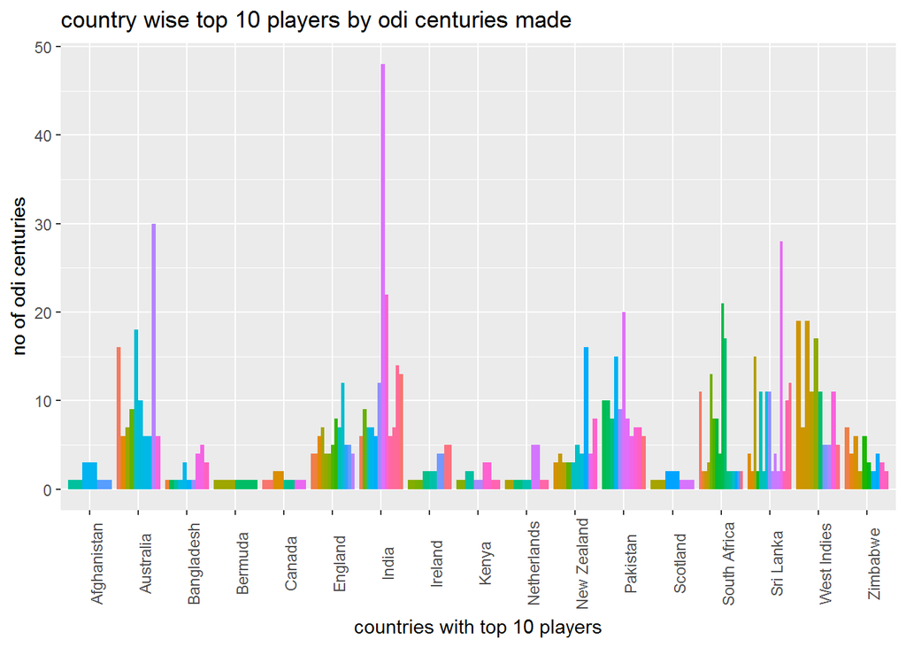

```r
ggplot(country_player_century,aes(x=Country,y=centuries))+geom_bar(aes(fill=Player),position="dodge",stat="identity")+theme(legend.position = "none")+theme(axis.text.x = element_text(angle=90))+xlab("countries with top 10 players")+ylab("no of odi centuries")+ggtitle("country wise top 10 players by odi centuries made")
```

# grouped bar chart of country wise top 10 players by average score rate

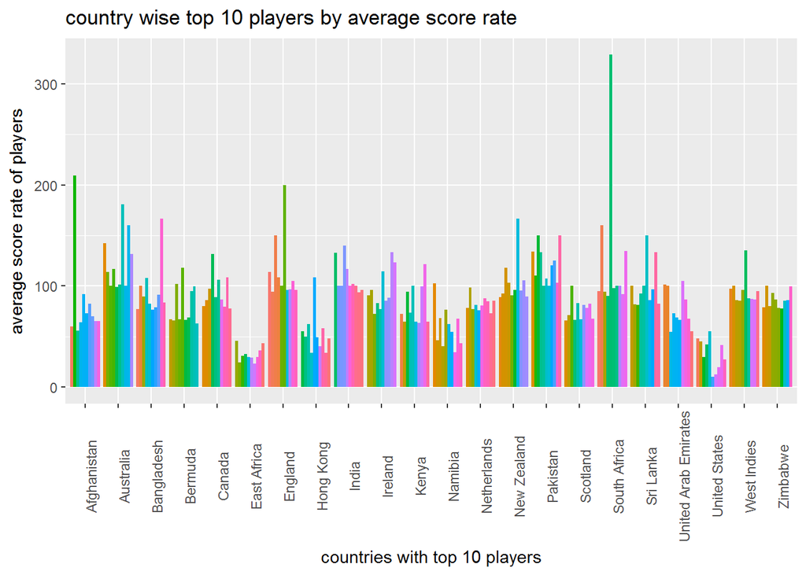

```r
ggplot(country_player_scorerate,aes(x=Country,y=avg_scorerate))+geom_bar(aes(fill=Player),position="dodge",stat="identity")+theme(legend.position = "none")+theme(axis.text.x = element_text(angle=90))+xlab("countries with top 10 players")+ylab("average score rate of players")+ggtitle("country wise top 10 players by average score rate")
```

# bar chart of top 10 grounds by total matches played

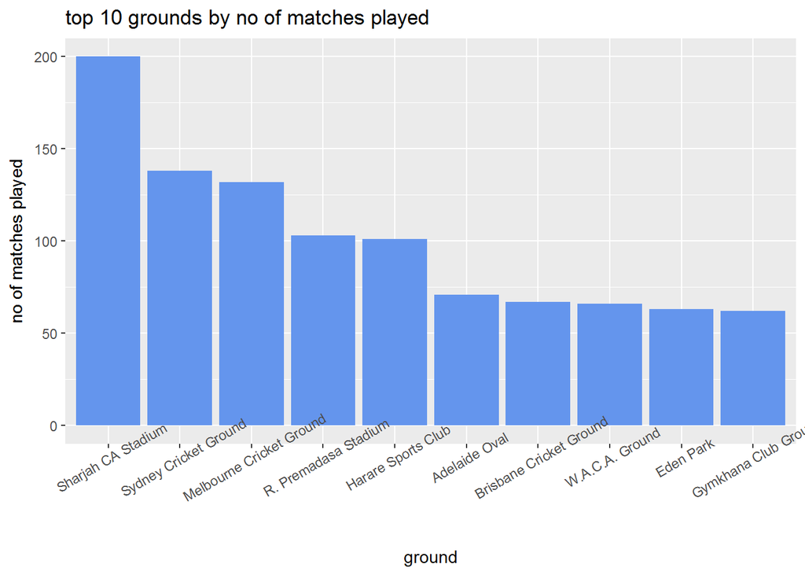

```r
ggplot(ground_match[1:10,],aes(x=reorder(Ground,-totalmatch),y=totalmatch))+geom_bar(stat="identity",fill="cornflowerblue")+xlab("ground")+ylab("no of matches played")+ggtitle("top 10 grounds by no of matches played")+theme(axis.text.x = element_text(angle = 30))
```

# bar chart of top 10 countries by total runs scored against india

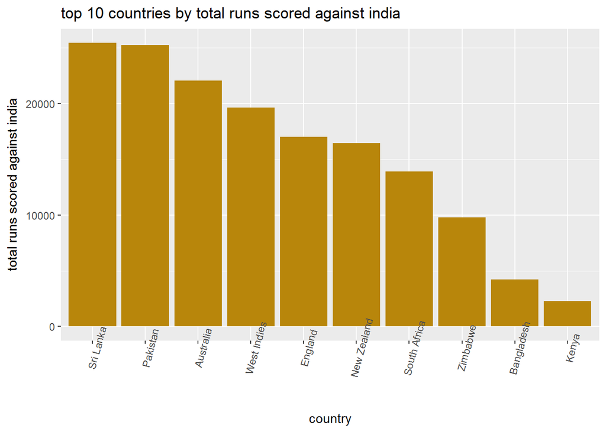

```r
ggplot(versus_india[1:10,],aes(x=reorder(Country,-totalruns),y=totalruns))+geom_bar(stat="identity",fill="darkgoldenrod")+xlab("country")+ylab("total runs scored against india")+ggtitle("top 10 countries by total runs scored against india")+theme(axis.text.x = element_text(angle = 75),)
```

# bar chart of top 10 players by batting average

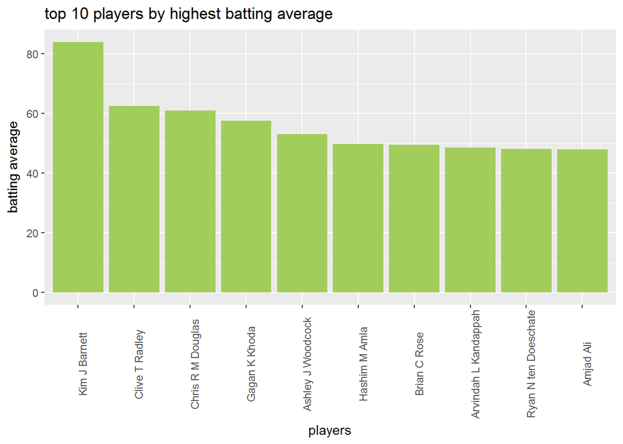

```r
ggplot(player_average[1:10,],aes(x=reorder(Player,-avg),y=avg))+geom_bar(stat = "identity",fill="darkolivegreen3")+theme(axis.text.x = element_text(angle = 90))+xlab("players")+ylab("batting average")+ggtitle("top 10 players by highest batting average")
```

# grouped bar chart of country wise top 10 players by batting average

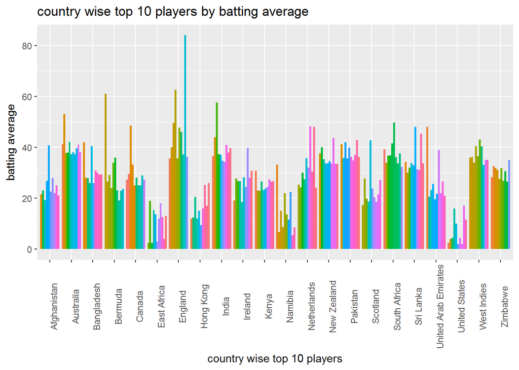

```r
ggplot(country_player_average,aes(x=Country,y=avg))+geom_bar(aes(fill=Player),position = "dodge",stat = "identity")+theme(axis.text.x = element_text(angle = 90))+xlab("country wise top 10 players")+ylab("batting average")+ggtitle("country wise top 10 players by batting average")+theme(legend.position = "none")
```